# Repaso

Teresa Ortiz

9/19/2017

### Conceptos de inferencia

La inferencia estadística o “aprender” (como se denota en ciencias de la computación), es el proceso de usar datos para inferir la distribución que generó los datos.

Muchos problemas de inferencia se pueden clasificar en alguna de las siguientes clases: estimación, intervalos de confianza, o pruebas de hipótesis.

La estimación puntual se refiere a dar un único valor para aproximar una cantidad de interés, es común que la cantidad de interés sea un parámetro del modelo, por ejemplo, la media, la correlación, la mediana o la varianza. Los estimadores *plug-in* de la media, varianza, mediana, … son estimadores puntuales.

Ejemplo: Supongamos que tenemos una muestra de 500 primarias de Cd. México y nos interesa conocer la media de la calificación en la prueba ENLACE de español. Notar que nos interesa la cantidad poblacional y no la media en la muestra.

```r
set.seed(17921)
n <- 500
N <- nrow(prim)
prim_muestra <- sample_n(prim, n, replace = TRUE)

# estimador puntual de la media
(theta_hat <- mean(prim_muestra$esp3))
```

```
## [1] 575.3217
```

```r
# valor poblacional
(theta <- mean(prim$esp3))
```

```
## [1] 574.7749
```

### Intervalos de confianza

En la primera sección de *bootstrap* nos centramos en estudiar errores estándar, esto es porque los errores estándar se utilizan para aproximar intervalos de confianza de un parámetro $\theta$ de interés. Dados una estimación $\theta$ y una estimación del error estándar $\hat{se}$, el intervalo usual de $90%$ de confianza para $\theta$ es
$$(\hat{\theta} - 1.645\hat{se}, \hat{\theta} + 1.645\hat{se})$$
este es un estimador de intervalo. Usualmente es más útil contar con una estimación de intervalo que con una estimación puntual. Al contar con ambos, nos dicen cual es nuestra mejor propuesta para $\theta$, y que tan lejos puede estar el verdadero valor de nuestra propuesta.

En nuestro ejemplo estimamos el error estándar usando bootstrap

```r
# error estándar bootstrap
se_hat <- rerun(1000, sample(prim_muestra$esp3, size = n, replace = TRUE)) %>%
    map_dbl(mean) %>%
    sd()
se_hat
```

```
## [1] 3.730789
```

Y obtenemos el intervalo del 90% de confianza:

```r
round(c(theta_hat - 1.645 * se_hat, theta_hat + 1.645 * se_hat), 1)
```

```
## [1] 569.2 581.5
```

Ahora, si estamos en la situación donde los datos se obtuvieron simplemente con un muestreo aleatorio de una distribución desconocida $P, P\to x = (x_1,...,x_n)$. Sea $\hat{\theta}=t(P_n)$ un estimador *plug-in* (estimador puntual) de un parámetro de interés $\theta=t(P)$, y sea $\hat{se}$ una estimación bootstrap del error estándar de $\hat{\theta}$. Bajo condiciones bastante generales resulta que conforme el tamaño de muestra $n$ aumenta, la distribución de $\hat{\theta}$ se aproxima más y más a una normal, con media $\theta$ y varianza cercana a $\hat{se}$,

$$\frac{\hat{\theta} - \theta}{\hat{se}}\overset{\cdot}{\sim} N(0,1)$$

Comparemos la distribución de $\hat{\theta}_n$ para distintos tamaños de muestra, tomaremos muestras de tamaño 5, 20, 100 y 500.

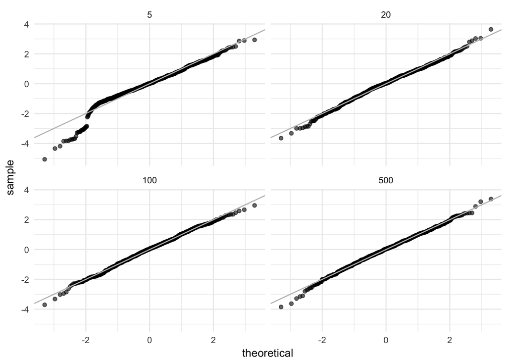

```r
calcula_thetas <- function(n){
    thetas <- rerun(1000, sample(prim$esp3, n, replace = TRUE)) %>%
        map_dbl(mean)
}

sims <- map_df(set_names(c(5, 20, 100, 500), c(5, 20, 100, 500)), ~calcula_thetas(.))

sims %>%
    gather(n, theta_hat) %>%
    mutate(n = as.numeric(n)) %>%
    group_by(n) %>%
    mutate(theta_z = (theta_hat - mean(theta_hat)) / sd(theta_hat)) %>%
    ggplot() +
        stat_qq(aes(sample = theta_z), alpha = 0.6) +
        geom_abline(color = "gray") +
        facet_wrap(~n)
```

Entonces, denotemos por $z^{(\alpha)}$ al percentil $100 \cdot \alpha$ de una $N(0,1)$, $z^{(.05)}=-1.645$, $z^{(.95)}=1.645$, $z^{(.025)}=-1.960$ y $z^{(.975)}=1.960$, entonces usando la aproximación de arriba tenemos

$$P\bigg(z^{(\alpha)} \le \frac{\hat{\theta} - \theta}{\hat{se}}\le z^{(1-\alpha)}\bigg) = 1-2\alpha$$
que se puede escribir como

$$P(\theta \in [\hat{\theta}-z^{(1-\alpha)} \cdot \hat{se}, \hat{\theta}-z^{(\alpha)} \cdot \hat{se}]) = 1-2\alpha$$

En general el intervalo $[\hat{\theta}-z^{(1-\alpha)} \cdot \hat{se}, \hat{\theta}-z^{(\alpha)} \cdot \hat{se}]$ se como intervalo de confianza estándar con nivel de confianza $(1-2\alpha)%$ para $\theta$.

La propiedad de cobertura de este intervalo implica que el $(1-2\alpha)%$ de las veces, un intervalo construido de esta manera va a contener el verdadero valor $\theta$. Recordemos que se construyó usando la aproximación Normal, y aunque muy útil y con gran aplicación hay ocasiones en los que hay mejores maneras de construir intervalos de confianza usando bootstrap.

Notemos que la definición de intervalo de confianza no requiere de errores estándar.

Un **intervalo de confianza** $1-2\alpha$ para un parámetro $\theta$ es un intervalo tal que $P(a \le \theta \le) \ge 1-2\alpha$ para todo $\theta \in \Theta$.

Y como vimos los percentiles bootstrap son una alternativa cuando la aproximación normal no es razonable.

```r
library(tidyverse)

load("../05-bootsrap/datos/base_completa.Rdata")

prim <- tbl_df(primaria) %>%
    filter(entidad == "DISTRITO FEDERAL", !is.na(esp.3), !is.na(esp.6)) %>%
    select(clave, turno, tipo = tipo.esc, mun = clave.mun, esp3 = esp.3,
        esp6 = esp.6) %>%
    mutate(tipo = as.character(tipo))

set.seed(17921)
n <- 500
N <- nrow(prim)
prim_muestra <- sample_n(prim, n, replace = TRUE)

# estimador de la media
mean(prim_muestra$esp3)
```

```
## [1] 575.3217
```

```r
# valor poblacional
mean(prim$esp3)
```

```
## [1] 574.7749
```

```r
# error estándar fórmula
sqrt(sum((prim_muestra$esp3 - mean(prim_muestra$esp3)) ^ 2 / n-1)) / sqrt(n)
```

```
## [1] 3.600169
```

```r
# error estándar bootstrap
rerun(1000, sample(prim_muestra$esp3, size = n, replace = TRUE)) %>%
    map_dbl(mean) %>%
    sd()
```

```
## [1] 3.730789
```

```r
# error estándar poblacional
sqrt(sum((prim$esp3 - mean(prim$esp3)) ^ 2 / N / n))
```

```
## [1] 3.722763
```

Es importante recordar que estamos haciendo inferencia y el estimador *plug-in*, el estimador del error estándar y el estimador de intervalo van a cambiar con la muestra.

¿Y si tomamos otra muestra?

```r
set.seed(102345)
prim_muestra <- sample_n(prim, n, replace = TRUE)

# estimador de la media
mean(prim_muestra$esp3)
```

```
## [1] 577.81
```

```r
# error estándar fórmula
sqrt(sum((prim_muestra$esp3 - mean(prim_muestra$esp3)) ^ 2 / n-1)) / sqrt(n)
```

```
## [1] 3.02422
```

```r
# error estándar bootstrap
rerun(1000, sample(prim_muestra$esp3, size = n, replace = TRUE)) %>%
    map_dbl(mean) %>%
    sd()
```

```
## [1] 3.212873
```

Un muy mal escenario (aunque posible)

```r
prim_muestra <- top_n(prim, n = n, wt = -esp3)

# estimador de la media
mean(prim_muestra$esp3)
```

```
## [1] 467.7497
```

```r
# error estándar fórmula
sqrt(sum((prim_muestra$esp3 - mean(prim_muestra$esp3)) ^ 2 / n-1)) / sqrt(n)
```

```
## [1] 4.694789
```

```r
# error estándar bootstrap
rerun(2000, sample(prim_muestra$esp3, size = n, replace = TRUE)) %>%
    map_dbl(mean) %>%
    sd()
```

```
## [1] 4.867574
```

### Tarea 6. ¿qué pasó?

Cobertura de intervalos de confianza. En este problema realizarás un ejercicio de simulación para comparar intervalos de confianza. Utiliza la función rnorm para simular muestras de tamaño 10 de una distribución normal estándar, el estadístico de interés es $\theta=exp(\mu)$.

| Método | % fallo izquierda | % fallo derecha | cobertura (simulaciones) |
| --- | --- | --- | --- |
| Normal |  |  |  |
| Percentiles |  |  |  |
| BC_a |  |  |  |

La columna cobertura es una estimación de la cobertura del intervalo basada en las simulaciones, para calcularla simplemente escribe el porcentaje de los intervalos que incluyeron el verdadero valor del parámetro. Recuerda usar la semilla.

2. Realiza una gráfica de páneles, en cada panel mostrarás los resultados de uno de los métodos (normal, percentiles y BC_a), el eje x corresponderá al número de intervalo de confianza ($1,...,500$) y en el vertical graficarás los límites de los intervalos, es decir graficarás 2 líneas (usa geom_line) una corresponderá a los límites inferiores de los intervalos, y otra a los superiores.

```r
library(bootstrap)
set.seed(38972938)
calcula_intervalos <- function(n = 10){
    x <- rnorm(n)
    theta <- exp(mean(x))    # theta_hat
    theta_b <- rerun(1000, sample(x, size = n, replace = TRUE)) %>%
        map_dbl(~exp(mean(.)))
    bca <- bcanon(x, nboot = 1000, theta = function(y) exp(mean(y)), alpha = c(0.025, 0.975))$confpoints[,2]  #       intervalos BC_a
    intervalos <- data_frame(metodo = c("normal", "percent", "BC_a"),
        izq = c(theta - 1.96 * sd(theta_b), quantile(theta_b, probs = 0.025), bca[1]),
        der = c(theta + 1.96 * sd(theta_b), quantile(theta_b, probs = 0.975), bca[2])
    )
}

sims_intervalos_10 <- rerun(500, calcula_intervalos())
sims_intervalos_10 %>%
    bind_rows() %>%
    group_by(metodo) %>%
        summarise(
            falla_izq = 100 * sum(izq > 1) / 500,
            falla_der = 100 * sum(der < 1) / 500
            )
```

```
## # A tibble: 3 x 3
##    metodo falla_izq falla_der
##     <chr>     <dbl>     <dbl>
## 1    BC_a       4.6       5.2
## 2  normal       2.2       6.6
## 3 percent       5.4       5.0
```

```r
sims_intervalos_50 <- rerun(500, calcula_intervalos(n = 50))
sims_intervalos_50 %>%
    bind_rows() %>%
    group_by(metodo) %>%
        summarise(
            falla_izq = 100 * sum(izq > 1) / 500,
            falla_der = 100 * sum(der < 1) / 500
            )
```

```
## # A tibble: 3 x 3
##    metodo falla_izq falla_der
##     <chr>     <dbl>     <dbl>
## 1    BC_a       1.8       2.2
## 2  normal       1.0       3.6
## 3 percent       2.2       2.8
```